# Homework 5

Steve Harms

March 7, 2019

## 1.)

Verify the conclusions on the distribution of $\widehat{\beta}_{k}$ and $\mbox{Cov}(\widehat{\beta}_{k}, \widehat{\beta}_{i})$.

From the notes, we have that $\hat{\beta}_k = (A'A)^{-1}A'X$. Note that because the error vector $\boldsymbol{\epsilon}$ is assumed MVN and $A$ is a linear transformation, that $\hat{\beta}$ is a linear combination of MVNs so it is also multivariate normal and thus $\hat{\beta_k}$ is normal for any $k$. We specify that $\epsilon$ is independent of $X$, so that the expected value is
$$\begin{equation}
E\lbrack\hat{\beta}_k\rbrack = E[(A'A)^{-1}A'X]\\
= (A'A)^{-1}A'(A\beta + \epsilon)\\
= (A'A)^{-1}A'A\beta + (A'A)^{-1}A'\epsilon)\\
= \beta + (A'A)^{-1}A'\epsilon)\\
= \beta + 0\\
=\beta\\
\end{equation}$$
The variance of $\hat{\beta_k}$ is given by
$$\begin{equation}
E\lbrack\hat{\beta_k}\hat{\beta_k}'\rbrack = E[((A'A)^{-1}A'X_k)((A'A)^{-1}A'X_k)']$\\
= (A'A)^{-1}A'E[X_kX_k']A(A'A)^{-1} \\
= (A'A)^{-1}A'\sigma_{kk} A(A'A)^{-1} \\
= \sigma_{kk}(A'A)^{-1}A'A(A'A)^{-1}] \\
=\sigma_{kk}(A'A)^{-1}\\
\end{equation}$$
The covariance of $\hat{\beta_k}$ and $\hat{\beta_i}$ is given by
$$\begin{equation}
E\lbrack\hat{\beta_k}'\hat{\beta_i}\rbrack = E[((A'A)^{-1}A'X_k)((A'A)^{-1}A'X_i)'] \\
= E[(A'A)^{-1}AE[X_kX_i']A(A'A)^{-1}] \\
= (A'A)^{-1}A'\sigma_{ki} A(A'A)^{-1}\\
= \sigma_{ki}(A'A)^{-1}A'A(A'A)^{-1}] \\
=\sigma_{ki}(A'A)^{-1}\\
\end{equation}$$

## 2.)

#### **(a)** Provide appropriate graphical summaries for the dataset.Comment on the distinctiveness between the chemical composition of the olive oils in the three main regions, as well as individually between the sub-regions. Can you see interactions between regions and chemical components?

Plots are provided below, one with all of the groups together and another with facets by region. All of the plots look very close to each other, and there are not many differences in the pattern across regions. Visually there is not much evidence for interaction (lines do not cross much). There is some slight evidence for interaction in the pattern for chemicals 4,5, and 6, where it appears the lines cross. However, we also know from the previous homework assignment that chemicals 4 and 5 also have the largest variance so it is still difficult to tell.

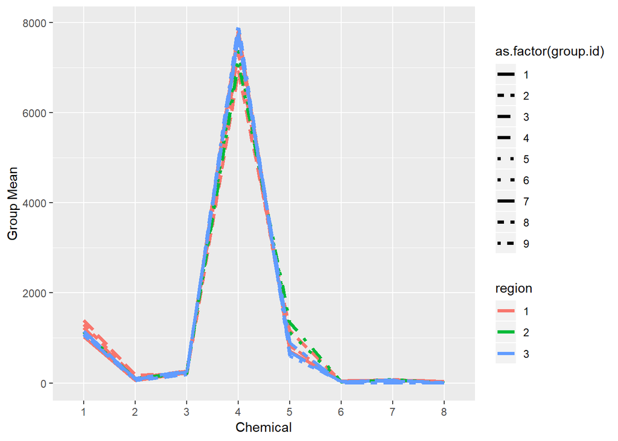

```r
olives <- read.delim('olive.dat', sep="")
#melt and summarize the data
summed <- olives %>% mutate(region = as.factor(ifelse(group.id < 5, 1, ifelse(group.id > 6, 3 , 2)))) %>%
  melt(id=c('group.id','region')) %>% group_by(region,group.id,variable) %>% summarise( grmean = mean(value)) %>%
  mutate(variable=as.numeric(str_sub(variable,-1L)))
#plot
#all
summed %>% ggplot(aes(x= as.factor(variable), y=grmean)) +
  geom_line(aes(group=as.factor(group.id), linetype=as.factor(group.id), color=region), size=1.3) +
  labs(x="Chemical", y="Group Mean")
```

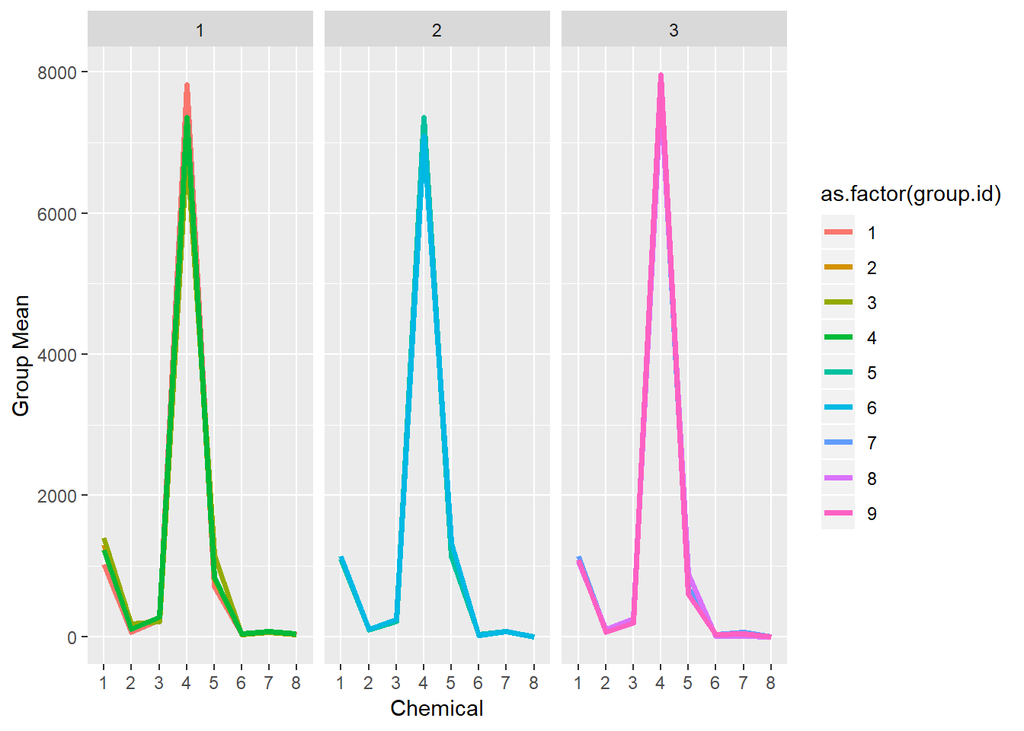

```r
#facet by region
summed %>% ggplot(aes(x= as.factor(variable), y=grmean)) +
  geom_line(aes(group=as.factor(group.id), color=as.factor(group.id)), size=1.3) +
  labs(x="Chemical", y="Group Mean") + facet_wrap('region')
```

#### **(b)** Perform a one-way multivariate analysis of variance to test for differences in mean chemical com- position among the three regions.

In the test below, we can see that the Wilks test statistic is quite small, resulting in a p-value that is near 0. Thus we reject the null hypothesis of equal mean vectors across regions and have evidence that the mean chemical composition is different for at least one region.

```r
#need to specify regions
olives <- olives %>% mutate(region = as.factor(ifelse(group.id < 5, 1, ifelse(group.id > 6, 3 , 2))), group.id=as.factor(group.id))
#fit the model
fitlm <- lm(as.matrix(olives[,2:9])~olives$region)
manolive <- Manova(fitlm)
summary(manolive)
```

```
##
## Type II MANOVA Tests:
##
## Sum of squares and products for error:
##              X1          X2          X3          X4          X5
## X1   8712198.47  2068166.15 -591367.187 -16398164.0   6354230.6
## X2   2068166.15   951933.35 -239198.820  -5452822.8   3032723.5
## X3   -591367.19  -239198.82  769685.235    808789.9   -875296.2
## X4 -16398163.97 -5452822.78  808789.900  44385022.5 -24868011.8
## X5   6354230.60  3032723.49 -875296.171 -24868011.8  18479382.0
## X6    -67379.53   -99478.02    7021.735    480314.3   -494033.2
## X7     74669.45   -78000.09   -8832.249    266028.7   -546173.8
## X8   -143122.66   -59386.98   42218.812    349340.4   -259104.5
##             X6          X7          X8
## X1  -67379.527   74669.446 -143122.657
## X2  -99478.020  -78000.087  -59386.983
## X3    7021.735   -8832.249   42218.812
## X4  480314.317  266028.691  349340.368
## X5 -494033.183 -546173.842 -259104.523
## X6   66053.027   66956.405    9721.942
## X7   66956.405  183120.455   17177.110
## X8    9721.942   17177.110   22808.041
##
## ------------------------------------------
##
## Term: olives$region
##
## Sum of squares and products for the hypothesis:
##              X1           X2           X3          X4          X5
## X1   7517535.24  2154506.818  -11358.7365 -16313012.3   4413510.5
## X2   2154506.82   621547.557   -5516.9112  -4916126.6   1491309.0
## X3    -11358.74    -5516.911    1273.3995    158440.7   -132434.2
## X4 -16313012.29 -4916126.629  158440.7153  49648363.2 -22971632.2
## X5   4413510.54  1491308.999 -132434.1755 -22971632.2  15181902.6
## X6    466041.97   135673.062   -1874.3508  -1135935.4    390761.0
## X7    409500.04   134446.801  -10109.2121  -1899371.6   1190534.3
## X8    823641.31   235143.784    -739.1389  -1733475.8    432963.5
##              X6          X7            X8
## X1   466041.967   409500.04   823641.3147
## X2   135673.062   134446.80   235143.7841
## X3    -1874.351   -10109.21     -739.1389
## X4 -1135935.429 -1899371.59 -1733475.8370
## X5   390760.974  1190534.28   432963.5194
## X6    29981.812    34226.86    50590.0723
## X7    34226.860    94004.06    41048.1276
## X8    50590.072    41048.13    90443.6429
##
## Multivariate Tests: olives$region
##                  Df test stat approx F num Df den Df     Pr(>F)
## Pillai            2  1.593690 276.0350     16   1126 < 2.22e-16 ***
## Wilks             2  0.031702 324.3008     16   1124 < 2.22e-16 ***
## Hotelling-Lawley  2 10.816547 379.2552     16   1122 < 2.22e-16 ***
## Roy               2  8.494086 597.7713      8    563 < 2.22e-16 ***
## ---
## Signif. codes:  0 '***' 0.001 '**' 0.01 '*' 0.05 '.' 0.1 ' ' 1
```

#### **(c)** Test for the interaction between regions and chemical components. What are the $C$ and $M$ matrices being used in this hypothesis?

C and M matrices are given below. From the output summary, we have a p-value near 0 for the Wilks statistic. Thus we reject the null hypothesis of no interaction between chemical/region. We have evidence of interaction effects

```r
#specify M matrix
M = rbind(c(1,-1,rep(0,times=6)),
          c(0,1,-1,rep(0,times=5)),
          c(0,0,1,-1, rep(0,times=4)),
          c(rep(0,times=3),1,-1,rep(0,times=3)),
          c(rep(0,times=4),1,-1, rep(0,times=2)),
          c(rep(0,times=5),1,-1,0),
          c(rep(0,times=6),1,-1))
t(M)
```

```
##      [,1] [,2] [,3] [,4] [,5] [,6] [,7]
## [1,]    1    0    0    0    0    0    0
## [2,]   -1    1    0    0    0    0    0
## [3,]    0   -1    1    0    0    0    0
## [4,]    0    0   -1    1    0    0    0
## [5,]    0    0    0   -1    1    0    0
## [6,]    0    0    0    0   -1    1    0
## [7,]    0    0    0    0    0   -1    1
## [8,]    0    0    0    0    0    0   -1
```

```r
#C matrix
C <- rbind(c(0,1,0),
           c(0,1,-1))
C
```

```
##      [,1] [,2] [,3]
## [1,]    0    1    0
## [2,]    0    1   -1
```

```r
#Hypothesis Test for Interactions
fitint.cm <- linearHypothesis(model = fitlm, hypothesis.matrix = C, P=t(M))
fitint.cm
```

```
##
##  Response transformation matrix:
##    [,1] [,2] [,3] [,4] [,5] [,6] [,7]
## X1    1    0    0    0    0    0    0
## X2   -1    1    0    0    0    0    0
## X3    0   -1    1    0    0    0    0
## X4    0    0   -1    1    0    0    0
## X5    0    0    0   -1    1    0    0
## X6    0    0    0    0   -1    1    0
## X7    0    0    0    0    0   -1    1
## X8    0    0    0    0    0    0   -1
##
## Sum of squares and products for the hypothesis:
##              [,1]        [,2]        [,3]        [,4]        [,5]
## [1,]   3830069.16  1538801.09  11391043.8 -14319087.2   2591832.6
## [2,]   1538801.09   633854.78   5067777.0  -6698310.5   1486195.8
## [3,]  11391043.84  5067777.03  49332755.2 -72329120.5  21705136.9
## [4,] -14319087.21 -6698310.52 -72329120.5 110773530.1 -36626838.3
## [5,]   2591832.64  1486195.76  21705136.9 -36626838.3  14430362.4
## [6,]     55315.66    -7008.60   -755201.3   1563209.5   -795528.3
## [7,]   -313444.29   -91326.91    156525.7   -923466.5    773934.0
##            [,6]       [,7]
## [1,]   55315.66 -313444.29
## [2,]   -7008.60  -91326.91
## [3,] -755201.30  156525.68
## [4,] 1563209.47 -923466.51
## [5,] -795528.25  773933.97
## [6,]   55532.15  -69319.15
## [7,]  -69319.15  102351.45
##
## Sum of squares and products for error:
##             [,1]         [,2]         [,3]        [,4]         [,5]
## [1,]   5527799.5   1468401.18  10593172.83 -14266848.3   3289408.61
## [2,]   1468401.2   2200016.22   5252728.62 -10169632.3   4014519.42
## [3,]  10593172.8   5252728.62  43537127.94 -67568948.3  24466008.23
## [4,] -14266848.3 -10169632.34 -67568948.26 112600428.1 -44321741.31
## [5,]   3289408.6   4014519.42  24466008.23 -44321741.3  19533501.39
## [6,]   -120571.0    -37331.92   -198431.64    162145.0     53044.04
## [7,]    236405.2     32437.96     32260.62    203757.6   -344303.78
##            [,6]       [,7]
## [1,] -120571.04  236405.21
## [2,]  -37331.92   32437.96
## [3,] -198431.64   32260.62
## [4,]  162144.97  203757.64
## [5,]   53044.04 -344303.78
## [6,]  115260.67 -108708.88
## [7,] -108708.88  171574.27
##
## Multivariate Tests:
##                  Df test stat approx F num Df den Df     Pr(>F)
## Pillai            2  1.567412 291.9375     14   1128 < 2.22e-16 ***
## Wilks             2  0.039526 324.1159     14   1126 < 2.22e-16 ***
## Hotelling-Lawley  2  8.944258 359.0481     14   1124 < 2.22e-16 ***
## Roy               2  6.627284 533.9698      7    564 < 2.22e-16 ***
## ---
## Signif. codes:  0 '***' 0.001 '**' 0.01 '*' 0.05 '.' 0.1 ' ' 1
```

#### **(d)** Test for the equivalence of means of chemical components among the 4 areas within region R1. What are the $C$ and $M$ matrices being used in this hypothesis?

(Assuming I understand what this question is asking) To test for equivalent mean chemical compositions, we want to test whether $\tau_{ik}-\tau_{jk}=0$ for any i or j. There is no need for an M matrix because we are not testing contrasts between specific chemicals (traits). This is the same as testing the between group differences in MANOVA like in part (b) above, except now we are using the group.id variable instead of the regions. There are multiple ways of testing this, the easiest way being the simple MANOVA but we can also specify contrasts. Some choices for the C matrix are given below. **In all cases, we get the same test statistic and the p-value is extremely small (near 0) for the Wilks statistic of .066872, so that even with a multiple testing correction we still will reject the null hypothesis. We have evidence to support the difference in mean chemical concentration for at least one of the combinations of areas in Region 1.**

```r
#get r1 only
olivesr1 <- olives %>% filter(region==1)
#fit new model
fitlmr <- lm(as.matrix(olivesr1[,2:9])~olivesr1$group.id)
manova.grp <- Manova(fitlmr)
summary(manova.grp)
```

```
##
## Type II MANOVA Tests:
##
## Sum of squares and products for error:
##              X1           X2          X3          X4          X5
## X1  3934289.841   745082.159  -86144.608 -6027256.96  1289927.74
## X2   745082.159   284392.364  -47440.601 -1315169.73   311870.54
## X3   -86144.608   -47440.601  308700.820   -45148.41  -175591.51
## X4 -6027256.961 -1315169.732  -45148.410 13244263.24 -5396561.43
## X5  1289927.737   311870.538 -175591.508 -5396561.43  3974742.70
## X6   -16553.373    -8686.072   13002.392   -20998.96    10841.60
## X7    93664.497    12645.495   -1309.131  -196669.04    31664.48
## X8    -2050.442    -1925.845    9224.609   -18242.96   -24065.92
##            X6          X7         X8
## X1 -16553.373   93664.497  -2050.442
## X2  -8686.072   12645.495  -1925.845
## X3  13002.392   -1309.131   9224.609
## X4 -20998.957 -196669.036 -18242.958
## X5  10841.603   31664.483 -24065.917
## X6  13787.371    7716.096   4829.008
## X7   7716.096   30237.289   8968.970
## X8   4829.008    8968.970  14883.540
##
## ------------------------------------------
##
## Term: olivesr1$group.id
##
## Sum of squares and products for the hypothesis:
##            X1          X2          X3          X4          X5          X6
## X1  3596992.4  1334482.27  -504206.37  -9276579.9   5339563.9 -107251.673
## X2  1334482.3   544078.95  -265092.86  -3662149.7   2318886.4  -52580.767
## X3  -504206.4  -265092.86   203177.68   1611505.1  -1264673.1   34326.354
## X4 -9276579.9 -3662149.67  1611505.09  25113579.7 -15399981.1  339480.762
## X5  5339563.9  2318886.36 -1264673.10 -15399981.1  10316622.1 -250350.070
## X6  -107251.7   -52580.77    34326.35    339480.8   -250350.1    6680.264
## X7  -159067.4   -64193.97    34906.72    412217.7   -260132.4    5520.433
## X8  -138932.5   -57270.55    32390.90    365513.0   -235531.9    5137.230
##             X7          X8
## X1 -159067.439 -138932.502
## X2  -64193.965  -57270.548
## X3   34906.719   32390.896
## X4  412217.683  365512.992
## X5 -260132.424 -235531.922
## X6    5520.433    5137.230
## X7    9898.240    8765.795
## X8    8765.795    7790.974
##
## Multivariate Tests: olivesr1$group.id
##                  Df test stat  approx F num Df   den Df     Pr(>F)
## Pillai            3  1.561753  42.62048     24 942.0000 < 2.22e-16 ***
## Wilks             3  0.066872  58.14938     24 905.4961 < 2.22e-16 ***
## Hotelling-Lawley  3  5.905260  76.44031     24 932.0000 < 2.22e-16 ***
## Roy               3  4.476791 175.71405      8 314.0000 < 2.22e-16 ***
## ---
## Signif. codes:  0 '***' 0.001 '**' 0.01 '*' 0.05 '.' 0.1 ' ' 1
```

```r
#Another way of doing it
#both choices of C matrix give us the same test statistics (see end of the output)
C.1 <- cbind(c(0,0,0),diag(3))
C.2 <- rbind(c(0,1,0,0), c(0,1,-1,0), c(0,1,0,-1))
C.1
```

```
##      [,1] [,2] [,3] [,4]
## [1,]    0    1    0    0
## [2,]    0    0    1    0
## [3,]    0    0    0    1
```

```r
C.2
```

```
##      [,1] [,2] [,3] [,4]
## [1,]    0    1    0    0
## [2,]    0    1   -1    0
## [3,]    0    1    0   -1
```

```r
linearHypothesis(model = fitlmr, hypothesis.matrix = C.1)
```

```
##
## Sum of squares and products for the hypothesis:
##            X1          X2          X3          X4          X5          X6
## X1  3596992.4  1334482.27  -504206.37  -9276579.9   5339563.9 -107251.673
## X2  1334482.3   544078.95  -265092.86  -3662149.7   2318886.4  -52580.767
## X3  -504206.4  -265092.86   203177.68   1611505.1  -1264673.1   34326.354
## X4 -9276579.9 -3662149.67  1611505.09  25113579.7 -15399981.1  339480.762
## X5  5339563.9  2318886.36 -1264673.10 -15399981.1  10316622.1 -250350.070
## X6  -107251.7   -52580.77    34326.35    339480.8   -250350.1    6680.264
## X7  -159067.4   -64193.97    34906.72    412217.7   -260132.4    5520.433
## X8  -138932.5   -57270.55    32390.90    365513.0   -235531.9    5137.230
##             X7          X8
## X1 -159067.439 -138932.502
## X2  -64193.965  -57270.548
## X3   34906.719   32390.896
## X4  412217.683  365512.992
## X5 -260132.424 -235531.922
## X6    5520.433    5137.230
## X7    9898.240    8765.795
## X8    8765.795    7790.974
##
## Sum of squares and products for error:
##              X1           X2          X3          X4          X5
## X1  3934289.841   745082.159  -86144.608 -6027256.96  1289927.74
## X2   745082.159   284392.364  -47440.601 -1315169.73   311870.54
## X3   -86144.608   -47440.601  308700.820   -45148.41  -175591.51
## X4 -6027256.961 -1315169.732  -45148.410 13244263.24 -5396561.43
## X5  1289927.737   311870.538 -175591.508 -5396561.43  3974742.70
## X6   -16553.373    -8686.072   13002.392   -20998.96    10841.60
## X7    93664.497    12645.495   -1309.131  -196669.04    31664.48
## X8    -2050.442    -1925.845    9224.609   -18242.96   -24065.92
##            X6          X7         X8
## X1 -16553.373   93664.497  -2050.442
## X2  -8686.072   12645.495  -1925.845
## X3  13002.392   -1309.131   9224.609
## X4 -20998.957 -196669.036 -18242.958
## X5  10841.603   31664.483 -24065.917
## X6  13787.371    7716.096   4829.008
## X7   7716.096   30237.289   8968.970
## X8   4829.008    8968.970  14883.540
##
## Multivariate Tests:
##                  Df test stat  approx F num Df   den Df     Pr(>F)
## Pillai            3  1.561753  42.62048     24 942.0000 < 2.22e-16 ***
## Wilks             3  0.066872  58.14938     24 905.4961 < 2.22e-16 ***
## Hotelling-Lawley  3  5.905260  76.44031     24 932.0000 < 2.22e-16 ***
## Roy               3  4.476791 175.71405      8 314.0000 < 2.22e-16 ***
## ---
## Signif. codes:  0 '***' 0.001 '**' 0.01 '*' 0.05 '.' 0.1 ' ' 1
```

```r
linearHypothesis(model = fitlmr, hypothesis.matrix = C.1)
```

[output not shown]

[output not shown]

```
##
## Sum of squares and products for the hypothesis:
##            X1          X2          X3          X4          X5          X6
## X1  3596992.4  1334482.27  -504206.37  -9276579.9   5339563.9 -107251.673
## X2  1334482.3   544078.95  -265092.86  -3662149.7   2318886.4  -52580.767
## X3  -504206.4  -265092.86   203177.68   1611505.1  -1264673.1   34326.354
## X4 -9276579.9 -3662149.67  1611505.09  25113579.7 -15399981.1  339480.762
## X5  5339563.9  2318886.36 -1264673.10 -15399981.1  10316622.1 -250350.070
## X6  -107251.7   -52580.77    34326.35    339480.8   -250350.1    6680.264
## X7  -159067.4   -64193.97    34906.72    412217.7   -260132.4    5520.433
## X8  -138932.5   -57270.55    32390.90    365513.0   -235531.9    5137.230
##             X7          X8
## X1 -159067.439 -138932.502
## X2  -64193.965  -57270.548
## X3   34906.719   32390.896
## X4  412217.683  365512.992
## X5 -260132.424 -235531.922
## X6    5520.433    5137.230
## X7    9898.240    8765.795
## X8    8765.795    7790.974
##
## Sum of squares and products for error:
##              X1           X2          X3          X4          X5
## X1  3934289.841   745082.159  -86144.608 -6027256.96  1289927.74
## X2   745082.159   284392.364  -47440.601 -1315169.73   311870.54
## X3   -86144.608   -47440.601  308700.820   -45148.41  -175591.51
## X4 -6027256.961 -1315169.732  -45148.410 13244263.24 -5396561.43
## X5  1289927.737   311870.538 -175591.508 -5396561.43  3974742.70
## X6   -16553.373    -8686.072   13002.392   -20998.96    10841.60
## X7    93664.497    12645.495   -1309.131  -196669.04    31664.48
## X8    -2050.442    -1925.845    9224.609   -18242.96   -24065.92
##            X6          X7         X8
## X1 -16553.373   93664.497  -2050.442
## X2  -8686.072   12645.495  -1925.845
## X3  13002.392   -1309.131   9224.609
## X4 -20998.957 -196669.036 -18242.958
## X5  10841.603   31664.483 -24065.917
## X6  13787.371    7716.096   4829.008
## X7   7716.096   30237.289   8968.970
## X8   4829.008    8968.970  14883.540
##
## Multivariate Tests:
##                  Df test stat  approx F num Df   den Df     Pr(>F)
## Pillai            3  1.561753  42.62048     24 942.0000 < 2.22e-16 ***
## Wilks             3  0.066872  58.14938     24 905.4961 < 2.22e-16 ***
## Hotelling-Lawley  3  5.905260  76.44031     24 932.0000 < 2.22e-16 ***
## Roy               3  4.476791 175.71405      8 314.0000 < 2.22e-16 ***
## ---
## Signif. codes:  0 '***' 0.001 '**' 0.01 '*' 0.05 '.' 0.1 ' ' 1
```

## 3)

#### **(a)** Take the log transformation of the data first, and then take the difference between consecutive years (current year minus previous year). Why this transformation provides the change rate of the number of crimes?

Taking the log is a way of converting it to percentage scale rather than absolute scale. We have taken the difference between a lagged variable, thus our new data is just the percent change from year to year.

```r
#filter the data
fbif <- fbiwide %>% filter(State%in%c("California","Iowa","Illinois", "District of Columbia", "New York"))
#log and lag
fbif <- fbif %>% mutate_at(vars(4:12), funs(log(.))) %>% data.frame() %>% mutate_at(vars(4:12), funs(.-lag(.)))
head(fbif)
```

```
##        State Abb Year Population Aggravated.assault   Burglary
## 1 California  CA 1961         NA                 NA         NA
## 2 California  CA 1962 0.03434869         0.04766704 0.07808959
## 3 California  CA 1963 0.03588348         0.07297942 0.10289538
## 4 California  CA 1964 0.02769701         0.11834324 0.11381457
## 5 California  CA 1965 0.02824153         0.06140085 0.13352187
## 6 California  CA 1966 0.01684475         0.12436172 0.07142509
##   Larceny.theft Legacy.rape Motor.vehicle.theft      Murder Rape
## 1            NA          NA                  NA          NA   NA
## 2    0.08547163 -0.02910391          0.05345833  0.08245556   NA
## 3    0.09812113  0.04448128          0.10171039  0.02406131   NA
## 4    0.10763486  0.16182063          0.17347537  0.09490486   NA
## 5    0.03728345  0.08645889          0.07602034  0.17327172   NA
## 6    0.06515149  0.11564183          0.06375250 -0.01373019   NA
##      Robbery
## 1         NA
## 2 0.05035569
## 3 0.05366898
## 4 0.12594558
## 5 0.12161490
## 6 0.05697656
```

#### **(b)** Use the transformed data to compare the change rates of different crimes. Summarize `Year` to three groups: from 1961 to 1980, from 1981 to 2000, from 2001 to 2017. Call this variable as `decade`. Perform a two-way Manova for the interaction between states and decade.

From the output summary, we see that the last Wilks test statistic (for the interaction between factors) is quite large, resulting in a p-value of .7616. Thus we fail to reject the null hypothesis. We do not have enough evidence to conclude that there is interaction between state and decade effects on the crime rate. However, we do have evidence for a difference in crime rates across decades.

```r
#add decade variable
fbid <- fbif %>% mutate(decade = as.factor(ifelse(between(Year,1961,1980), 1 ,
                                              ifelse(between(Year, 1981,2000), 2,
                                                 3)))) %>% select(-Rape) %>% filter(complete.cases(.))
#fit two-way Manova
#Fail to reject null hypothesis for difference between states (p=.2697)
#Reject null hypothesis for difference between decades (p~0)
#Fail to reject null hypothesis for interaction between states and decades (Wilks: p=.7616)
fittwo <- lm(as.matrix(fbid[,(5:11)]) ~ fbid$State * fbid$decade, data = fbid)
fit.manova.two <- Manova(fittwo)
summary(fit.manova.two)
```

```
##
## Type II MANOVA Tests:
##
## Sum of squares and products for error:
##                     Aggravated.assault  Burglary Larceny.theft Legacy.rape
## Aggravated.assault           2.1924693 0.3275148     0.5742981   0.8889270
## Burglary                     0.3275148 1.7782991     0.7715135   0.5441766
## Larceny.theft                0.5742981 0.7715135     1.1925846   0.5469812
## Legacy.rape                  0.8889270 0.5441766     0.5469812   5.1936396
## Motor.vehicle.theft          0.7474534 1.3647510     0.8349955   0.4314734
## Murder                       0.5658439 0.9791887     0.6610148   0.7948101
## Robbery                      1.0271205 1.6705702     1.0809129   0.9470569
##                     Motor.vehicle.theft    Murder   Robbery
## Aggravated.assault            0.7474534 0.5658439 1.0271205
## Burglary                      1.3647510 0.9791887 1.6705702
## Larceny.theft                 0.8349955 0.6610148 1.0809129
## Legacy.rape                   0.4314734 0.7948101 0.9470569
## Motor.vehicle.theft           3.0676230 1.2968384 1.8789799
## Murder                        1.2968384 5.2111708 2.0479232
## Robbery                       1.8789799 2.0479232 3.8730373
##
## ------------------------------------------
##
## Term: fbid$State
##
## Sum of squares and products for the hypothesis:
##                     Aggravated.assault    Burglary Larceny.theft
## Aggravated.assault         0.104334402 0.063362475   0.003973904
## Burglary                   0.063362475 0.052201119   0.009112422
## Larceny.theft              0.003973904 0.009112422   0.007859317
## Legacy.rape                0.047789025 0.027701063   0.007665953
## Motor.vehicle.theft        0.057024555 0.053709808   0.017966472
## Murder                     0.014735228 0.021634267   0.005478547
## Robbery                    0.037877182 0.028651439   0.011474525
##                     Legacy.rape Motor.vehicle.theft      Murder    Robbery
## Aggravated.assault  0.047789025          0.05702455 0.014735228 0.03787718
## Burglary            0.027701063          0.05370981 0.021634267 0.02865144
## Larceny.theft       0.007665953          0.01796647 0.005478547 0.01147453
## Legacy.rape         0.031706746          0.03216639 0.003158018 0.02615526
## Motor.vehicle.theft 0.032166393          0.08016283 0.027930643 0.04970596
```

[output cut: 66 more lines]

```
## Burglary             0.0108365775
## Larceny.theft       -0.0003713936
## Legacy.rape          0.0256422564
## Motor.vehicle.theft -0.0086695888
## Murder               0.0089949104
## Robbery              0.0521459023
##
## Multivariate Tests: fbid$State:fbid$decade
##                  Df test stat  approx F num Df   den Df    Pr(>F)
## Pillai            8 0.1829012 0.8551988     56 1785.000 0.7686577
## Wilks             8 0.8277793 0.8587238     56 1346.217 0.7615977
## Hotelling-Lawley  8 0.1954469 0.8630575     56 1731.000 0.7545194
## Roy               8 0.0948563 3.0235451      8  255.000 0.0029116 **
## ---
## Signif. codes:  0 '***' 0.001 '**' 0.01 '*' 0.05 '.' 0.1 ' ' 1
```

#### **(c)** Report and explain the sum of square matrices from question (b). Verify their sum is equal to the corrected total sum of squares matrix.

Each matrix is the portion of the total variation / covariance in the data (total SS) that is explained by adding that factor. We can see below that adding our 4 SS matrices from the model fit results in the same matrix that results from finding the total SS by definition.

```r
#SS matrices. The factors and interactions, then the error SS
SSm <- fit.manova.two$SSP %>% lapply(as.matrix)
SSm
```

```
## $`fbid$State`
##                     Aggravated.assault    Burglary Larceny.theft
## Aggravated.assault         0.104334402 0.063362475   0.003973904
## Burglary                   0.063362475 0.052201119   0.009112422
## Larceny.theft              0.003973904 0.009112422   0.007859317
## Legacy.rape                0.047789025 0.027701063   0.007665953
## Motor.vehicle.theft        0.057024555 0.053709808   0.017966472
## Murder                     0.014735228 0.021634267   0.005478547
## Robbery                    0.037877182 0.028651439   0.011474525
##                     Legacy.rape Motor.vehicle.theft      Murder    Robbery
## Aggravated.assault  0.047789025          0.05702455 0.014735228 0.03787718
## Burglary            0.027701063          0.05370981 0.021634267 0.02865144
## Larceny.theft       0.007665953          0.01796647 0.005478547 0.01147453
## Legacy.rape         0.031706746          0.03216639 0.003158018 0.02615526
## Motor.vehicle.theft 0.032166393          0.08016283 0.027930643 0.04970596
## Murder              0.003158018          0.02793064 0.015470008 0.01179992
## Robbery             0.026155258          0.04970596 0.011799920 0.03652266
##
## $`fbid$decade`
##                     Aggravated.assault  Burglary Larceny.theft Legacy.rape
## Aggravated.assault           0.3182465 0.4067347     0.3056657   0.2589150
## Burglary                     0.4067347 0.6608312     0.4681925   0.4399779
## Larceny.theft                0.3056657 0.4681925     0.3362188   0.3086571
## Legacy.rape                  0.2589150 0.4399779     0.3086571   0.2950158
## Motor.vehicle.theft          0.3201584 0.3968825     0.3007406   0.2509592
## Murder                       0.2622718 0.4225296     0.2999274   0.2809313
## Robbery                      0.4150804 0.6691861     0.4749374   0.4449799
##                     Motor.vehicle.theft    Murder   Robbery
## Aggravated.assault            0.3201584 0.2622718 0.4150804
## Burglary                      0.3968825 0.4225296 0.6691861
## Larceny.theft                 0.3007406 0.2999274 0.4749374
## Legacy.rape                   0.2509592 0.2809313 0.4449799
## Motor.vehicle.theft           0.3231540 0.2562318 0.4054798
## Murder                        0.2562318 0.2702335 0.4279759
## Robbery                       0.4054798 0.4279759 0.6777978
##
## $`fbid$State:fbid$decade`
##                     Aggravated.assault      Burglary Larceny.theft
## Aggravated.assault         0.115055454 -0.0113421428  0.0266093650
## Burglary                  -0.011342143  0.0081222478  0.0023100678
## Larceny.theft              0.026609365  0.0023100678  0.0252788755
## Legacy.rape               -0.007966065  0.0046498202  0.0111900032
## Motor.vehicle.theft        0.042279742  0.0013319810 -0.0054457396
## Murder                    -0.012968679 -0.0001990623 -0.0372890900
## Robbery                   -0.024079441  0.0108365775 -0.0003713936
##                      Legacy.rape Motor.vehicle.theft        Murder
## Aggravated.assault  -0.007966065         0.042279742 -0.0129686795
## Burglary             0.004649820         0.001331981 -0.0001990623
## Larceny.theft        0.011190003        -0.005445740 -0.0372890900
## Legacy.rape          0.039949475        -0.038637110 -0.0149734155
## Motor.vehicle.theft -0.038637110         0.091160625  0.0490054811
## Murder              -0.014973415         0.049005481  0.0952535686
## Robbery              0.025642256        -0.008669589  0.0089949104
##                           Robbery
## Aggravated.assault  -0.0240794406
## Burglary             0.0108365775
## Larceny.theft       -0.0003713936
## Legacy.rape          0.0256422564
## Motor.vehicle.theft -0.0086695888
## Murder               0.0089949104
## Robbery              0.0521459023
```

```r
#Error SS
fit.manova.two$SSPE
```

```
##                     Aggravated.assault  Burglary Larceny.theft Legacy.rape
## Aggravated.assault           2.1924693 0.3275148     0.5742981   0.8889270
## Burglary                     0.3275148 1.7782991     0.7715135   0.5441766
## Larceny.theft                0.5742981 0.7715135     1.1925846   0.5469812
## Legacy.rape                  0.8889270 0.5441766     0.5469812   5.1936396
## Motor.vehicle.theft          0.7474534 1.3647510     0.8349955   0.4314734
## Murder                       0.5658439 0.9791887     0.6610148   0.7948101
## Robbery                      1.0271205 1.6705702     1.0809129   0.9470569
##                     Motor.vehicle.theft    Murder   Robbery
## Aggravated.assault            0.7474534 0.5658439 1.0271205
## Burglary                      1.3647510 0.9791887 1.6705702
## Larceny.theft                 0.8349955 0.6610148 1.0809129
## Legacy.rape                   0.4314734 0.7948101 0.9470569
## Motor.vehicle.theft           3.0676230 1.2968384 1.8789799
## Murder                        1.2968384 5.2111708 2.0479232
## Robbery                       1.8789799 2.0479232 3.8730373
```

```r
#Do the SS/CP matrices add up to total SS?
fmt <- manova(as.matrix(fbid[,(5:11)]) ~ fbid$State * fbid$decade, data = fbid)
cov(fitted.values(fmt))+cov(fmt$residuals)
```

```
##                     Aggravated.assault    Burglary Larceny.theft
## Aggravated.assault         0.010172651 0.002960693   0.003407155
## Burglary                   0.002960693 0.009351856   0.004687001
## Larceny.theft              0.003407155 0.004687001   0.005827031
## Legacy.rape                0.004434453 0.003810238   0.003268679
## Motor.vehicle.theft        0.004374237 0.006810089   0.004304499
## Murder                     0.003109091 0.005328866   0.003476886
## Robbery                    0.005443067 0.008894127   0.005853143
##                     Legacy.rape Motor.vehicle.theft      Murder
## Aggravated.assault  0.004434453         0.004374237 0.003109091
## Burglary            0.003810238         0.006810089 0.005328866
## Larceny.theft       0.003268679         0.004304499 0.003476886
## Legacy.rape         0.020685630         0.002544605 0.003975076
## Motor.vehicle.theft 0.002544605         0.013290806 0.006095645
## Murder              0.003975076         0.006095645 0.020812984
## Robbery             0.005391618         0.008694586 0.009312759
##                         Robbery
## Aggravated.assault  0.005443067
## Burglary            0.008894127
## Larceny.theft       0.005853143
## Legacy.rape         0.005391618
## Motor.vehicle.theft 0.008694586
## Murder              0.009312759
## Robbery             0.017285435
```

```r
cov(as.matrix(fbid[,(5:11)]))
```

```
##                     Aggravated.assault    Burglary Larceny.theft
## Aggravated.assault         0.010172651 0.002960693   0.003407155
## Burglary                   0.002960693 0.009351856   0.004687001
## Larceny.theft              0.003407155 0.004687001   0.005827031
## Legacy.rape                0.004434453 0.003810238   0.003268679
## Motor.vehicle.theft        0.004374237 0.006810089   0.004304499
## Murder                     0.003109091 0.005328866   0.003476886
## Robbery                    0.005443067 0.008894127   0.005853143
##                     Legacy.rape Motor.vehicle.theft      Murder
## Aggravated.assault  0.004434453         0.004374237 0.003109091
## Burglary            0.003810238         0.006810089 0.005328866
## Larceny.theft       0.003268679         0.004304499 0.003476886
## Legacy.rape         0.020685630         0.002544605 0.003975076
## Motor.vehicle.theft 0.002544605         0.013290806 0.006095645
## Murder              0.003975076         0.006095645 0.020812984
## Robbery             0.005391618         0.008694586 0.009312759
##                         Robbery
## Aggravated.assault  0.005443067
## Burglary            0.008894127
## Larceny.theft       0.005853143
## Legacy.rape         0.005391618
## Motor.vehicle.theft 0.008694586
## Murder              0.009312759
## Robbery             0.017285435
```

```r
#Note that our groups are not balanced:
fbid %>% filter(State=='Illinois') %>% nrow()
```

```
## [1] 55
```

```r
fbid %>% filter(State=='New York') %>% nrow()
```

```
## [1] 50
```

#### **(d)** Use `Aggravated.assault - Burglary` and `Burglary - Larceny.theft`. Are there interaction effects between states and decades for the difference of the change rates among the three crimes?

From the output summary, the test statistic for interactions (last section) is quite large and the associated p-value is quite large (p=.488), so we fail to reject the null hypothesis. There is no evidence to support interactions between state and decade for the variable differences we tested.

```r
#Need M matrix to test differences
M <- rbind(c(1,-1,rep(0,times=5)),
           c(0,1,-1,rep(0,times=4)))
t(M)
```

```
##      [,1] [,2]
## [1,]    1    0
## [2,]   -1    1
## [3,]    0   -1
## [4,]    0    0
## [5,]    0    0
## [6,]    0    0
## [7,]    0    0
```

```r
#fit new model
fitcon <- lm(as.matrix(fbid[,(5:11)])%*%t(M) ~ fbid$State * fbid$decade)
fit.manova.con <- Manova(fitcon)
summary(fit.manova.con)
```

```
##
## Type II MANOVA Tests:
##
## Sum of squares and products for error:
##           [,1]      [,2]
## [1,]  3.315739 -1.253569
## [2,] -1.253569  1.427857
##
## ------------------------------------------
##
## Term: fbid$State
##
## Sum of squares and products for the hypothesis:
##            [,1]       [,2]
## [1,] 0.02981057 0.01629987
## [2,] 0.01629987 0.04183559
##
## Multivariate Tests: fbid$State
##                  Df test stat approx F num Df den Df    Pr(>F)
## Pillai            4 0.0661854 2.181864      8    510 0.0274805 *
## Wilks             4 0.9341044 2.201610      8    508 0.0260553 *
## Hotelling-Lawley  4 0.0702338 2.221145      8    506 0.0247146 *
## Roy               4 0.0654962 4.175383      4    255 0.0027131 **
## ---
## Signif. codes:  0 '***' 0.001 '**' 0.01 '*' 0.05 '.' 0.1 ' ' 1
##
## ------------------------------------------
##
## Term: fbid$decade
##
## Sum of squares and products for the hypothesis:
##             [,1]        [,2]
## [1,]  0.16560819 -0.09156957
## [2,] -0.09156957  0.06066493
##
## Multivariate Tests: fbid$decade
##                  Df test stat approx F num Df den Df     Pr(>F)
## Pillai            2 0.0626685 4.124347      4    510 0.00267997 **
## Wilks             2 0.9378242 4.142361      4    508 0.00259882 **
## Hotelling-Lawley  2 0.0657726 4.160115      4    506 0.00252127 **
## Roy               2 0.0564695 7.199866      2    255 0.00090831 ***
## ---
## Signif. codes:  0 '***' 0.001 '**' 0.01 '*' 0.05 '.' 0.1 ' ' 1
##
## ------------------------------------------
##
## Term: fbid$State:fbid$decade
##
## Sum of squares and products for the hypothesis:
##             [,1]        [,2]
## [1,]  0.14586199 -0.04376369
## [2,] -0.04376369  0.02878099
##
## Multivariate Tests: fbid$State:fbid$decade
##                  Df test stat  approx F num Df den Df  Pr(>F)
## Pillai            8 0.0591042 0.9706574     16    510 0.48782
## Wilks             8 0.9415754 0.9702172     16    508 0.48833
## Hotelling-Lawley  8 0.0613281 0.9697507     16    506 0.48886
## Roy               8 0.0454478 1.4486485      8    255 0.17667
```